# Naive_bayes_R-AnthonyMoubarak

2022-10-13

## Developing a Naive Bayes model to classify song era

This section focuses on building a Naive Bayes classification model that will be used to predict in what era (50s,60s,70s, all the way up to 2010s) a song was released in according to multiple music related features.

```r
# Import the data

df <- read.csv('/Users/anthonymoubarak/Desktop/anly-501-project-anthonymoub/501-project-website/Data/final_df.csv')

# Change the year column from showcasing a year to showcase a decade (ex: 1967 --> 60s)

for (i in 1:nrow(df)) {

    decade <- df$year[i]

    if (decade <1960) {
        df$year[i] = '50s'}

    else if (decade <1970){
        df$year[i] = '60s'}

    else if (decade <1980){
        df$year[i] = '70s'}

    else if (decade <1990) {
        df$year[i] = '80s'}

    else if (decade <2000) {
        df$year[i] = '90s'}

    else if (decade <2010) {
        df$year[i] = '00s'}

    else {
        df$year[i] = '2010s'}
}
```

```r
# Split the data into training and testing sets

#Setting seed ensures that you get the same result if you start with that same seed each time you run the same process

set.seed(1234)


#We split the data into 2 parts. First part consisting 90% of the data will be used as training set and the other 10% will be used as testing set.

index = sample(2,nrow(df),prob = c(0.9,0.1),replace=TRUE)


#training set

train = df[index==1,]



#testing set

test = df[index==2,]
```

### Method 1: Use all numerical features of the dataset in standard format to train the model

```r
### Train the Gaussian Naive Bayes
library(naivebayes)
# Normalize training and testing data
X_train <- train[, !names(train) %in% c("X" , "lyrics", "title" , "artist" , "year")]
y_train <- train[['year']]

X_test <- test[, !names(test) %in% c("X" , "lyrics", "title" , "artist", "year")]
y_test <- test[['year']]

gnb1 <- gaussian_naive_bayes(x = data.matrix(X_train), y = y_train)

ypred <- (predict(gnb1, newdata = data.matrix(X_test), type = "class"))
```

```r
# Testing accuracy of this method
accuracy_method1 <- round((sum(ypred==y_test)/length(y_test))*100 , digits = 0)
paste("Method 1 accuracy: " , accuracy_method1, "%")
```

```
## [1] "Method 1 accuracy:  40 %"
```

### Method 2: Normalize X

Since one of Gaussian Naive Bayes’s main assumptions is the normality of data, this method focuses on converting the numerical features to a normal scale and check whether or not this improves the model’s performance.

```r
# Define the columns to be normalized (all but year)


cols <- c("num_syllables" , "pos", "fog_index" ,"flesch_index", "num_words" , "num_lines" ,"f_k_grade" , "difficult_words" , "neg" ,"neu" ,"compound" , "danceability" ,"energy" ,"key" , "loudness"  ,"mode" ,  "speechiness" ,"acousticness" ,"instrumentalness","liveness" , "valence" , "tempo" ,"duration_ms" , "time_signature" )

# Create new training and testing sets that are normalized
X_train2 <- train[, !names(train) %in% c("X" , "lyrics", "title" , "artist" , "year")]
y_train2 <- train[['year']]

X_test2 <- test[, !names(test) %in% c("X" , "lyrics", "title" , "artist", "year")]
y_test2 <- test[['year']]


X_train2[cols] <- lapply(X_train2[cols], function(x) c(scale(x)))
X_test2[cols] <- lapply(X_test2[cols], function(x) c(scale(x)))

gnb2 <- gaussian_naive_bayes(x = data.matrix(X_train2), y = y_train2)
ypred_2 <- (predict(gnb2, newdata = data.matrix(X_test2), type = "class"))
sum(ypred_2==y_test2)/length(y_test2)
```

```
## [1] 0.4059829
```

```r
# Testing accuracy of this method
accuracy_method2 <- round((sum(ypred_2==y_test2)/length(y_test2))*100 , digits = 0)
paste("Method 2 accuracy: " , accuracy_method2, "%")
```

```
## [1] "Method 2 accuracy:  41 %"
```

Normalizing features does not seem to cause any accuracy improvements. The next method will be dropping dependent variables.

### Method 3: Dropping dependent variables

Since another Gaussian Naive Bayes major assumption is the independence of features, this method focuses on dropping all features that have some correlation with each other (based on correlation heat map done previously in the project)

Below is the correlation heatmap previously computed for this dataset:

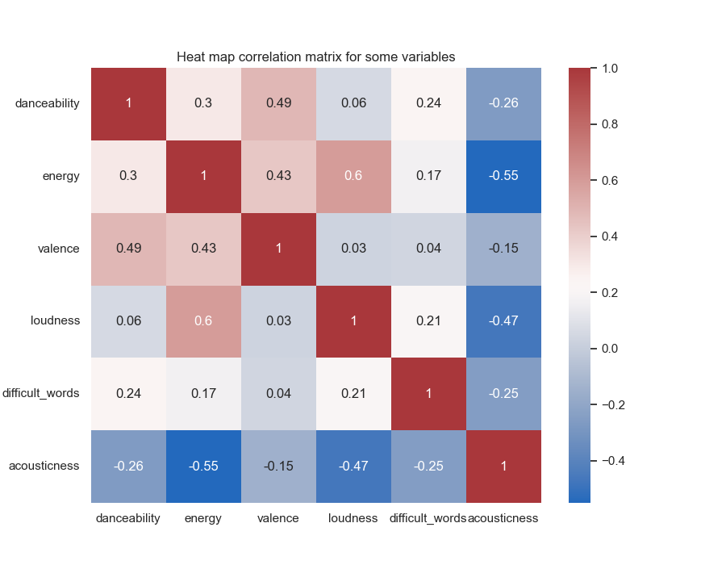

The above matrix shows that all of these features have some form of correlation with 1 or more features, which is why all of them will be dropped as they are far from being “independent”, which is the essence of naive bayes.

```r
# The correlated features are :
# "danceability" , "energy" , "valence", "loudness" , "difficult_words", "acousticness"

# Rebuild the NB model with the alternate features

X_train3 <- train[, !names(train) %in% c("X" , "lyrics", "title" , "artist","danceability" , "energy" , "valence", "loudness" , "difficult_words", "acousticness")]
y_train3 <- train[['year']]

X_test3  <- test[, !names(test) %in% c("X" , "lyrics", "title" , "artist","danceability" , "energy" , "valence", "loudness" , "difficult_words", "acousticness")]
y_test3 <- test[['year']]

# Normalize the new train and testing sets

new_cols <- c("num_syllables" , "pos", "fog_index" ,"flesch_index", "num_words" , "num_lines" ,"f_k_grade"  , "neg" ,"neu" ,"compound"  ,"key" ,"mode" ,  "speechiness" ,"instrumentalness","liveness"  , "tempo" ,"duration_ms" , "time_signature" )


X_train3[cols] <- lapply(X_train3[new_cols], function(x) c(scale(x)))
X_test3[cols] <- lapply(X_test3[new_cols], function(x) c(scale(x)))


gnb3 <- gaussian_naive_bayes(x = data.matrix(X_train3), y = y_train3)
ypred_3 <- (predict(gnb3, newdata = data.matrix(X_test3), type = "class"))
```

```r
# Testing accuracy of this method
accuracy_method3 <- round((sum(ypred_3==y_test3)/length(y_test3))*100 , digits = 0)
paste("Method 3 accuracy: " , accuracy_method3, "%")
```

```
## [1] "Method 3 accuracy:  86 %"
```

```r
# Create a random classifier

random_predictions <- c()
decades <- c('50s' , '60s' , '70s' , '80s' , '90s' , '00s' , '2010s')
for (i in 1:nrow(df)) {
  random_predictions <- append(random_predictions , sample(decades , 1))
}

# Accuracy
accuracy_random_classifier <- round((sum(random_predictions == df$year)/length(df$year))*100 , digits = 0)
paste("Random classifier accuracy: " , accuracy_random_classifier, "%")
```

```
## [1] "Random classifier accuracy:  14 %"
```

## Result analysis

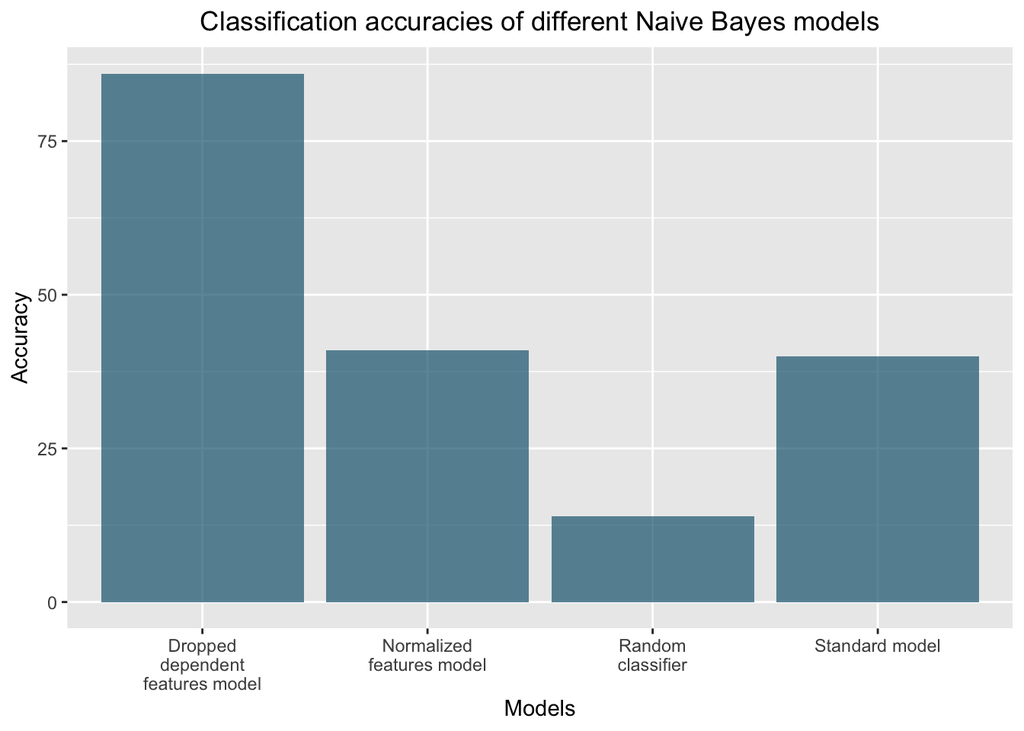

```r
# Plotting results of three different methods
library(ggplot2)
Models <- c("Standard model", "Normalized features model", "Dropped dependent features model" , "Random classifier")
Accuracy <- c(accuracy_method1 , accuracy_method2, accuracy_method3, accuracy_random_classifier)

df_results <- data.frame(Models , Accuracy)

ggplot(df_results, aes(x=Models, y=Accuracy)) +
  geom_bar(stat = "identity" , fill=rgb(0.1,0.4,0.5,0.7) ) + ggtitle('Classification accuracies of different Naive Bayes models') +
  theme(plot.title = element_text(hjust = 0.5)) +
  scale_x_discrete(labels = function(x)
    stringr::str_wrap(x, width = 15))
```

```r
ggsave("/Users/anthonymoubarak/Desktop/models.png")
# Confusion matrix (for the best model)
library(caret)
```

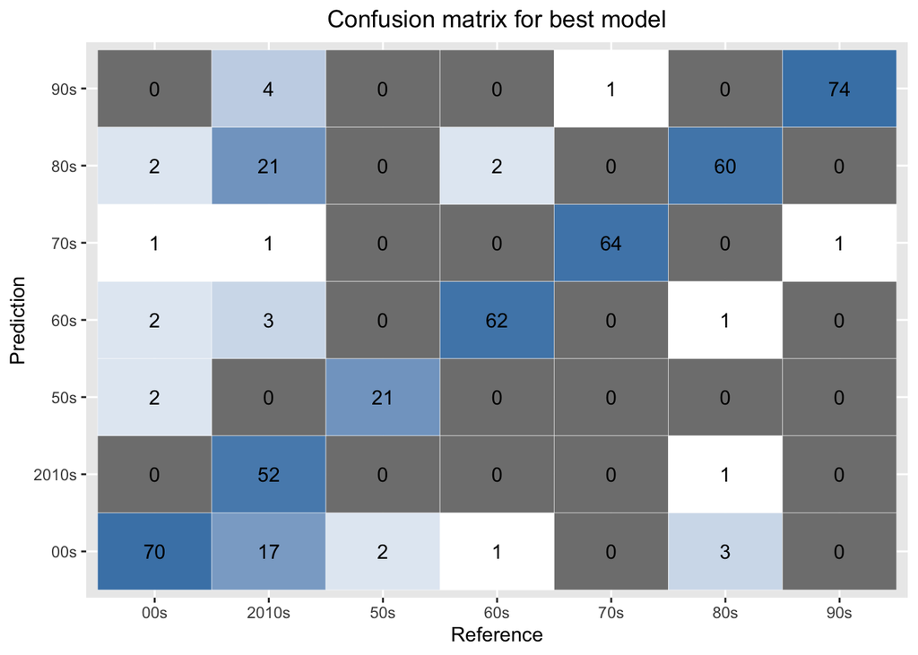

```r
cfm <- confusionMatrix(ypred_3, as.factor(y_test3))

ggplotConfusionMatrix <- function(m){
  p <-
    ggplot(data = as.data.frame(m$table) ,
           aes(x = Reference, y = Prediction)) +
    geom_tile(aes(fill = log(Freq)), colour = "white") +
    scale_fill_gradient(low = "white", high = "steelblue") +
    geom_text(aes(x = Reference, y = Prediction, label= Freq)) +
    theme(legend.position = "none") +
    ggtitle("Confusion matrix for best model") + theme(plot.title = element_text(hjust = 0.5))

  return(p)
}

ggplotConfusionMatrix(cfm)
```

```r
ggsave("/Users/anthonymoubarak/Desktop/confusion_matrix_R.png")
```